# Retail Project

### Code Setup

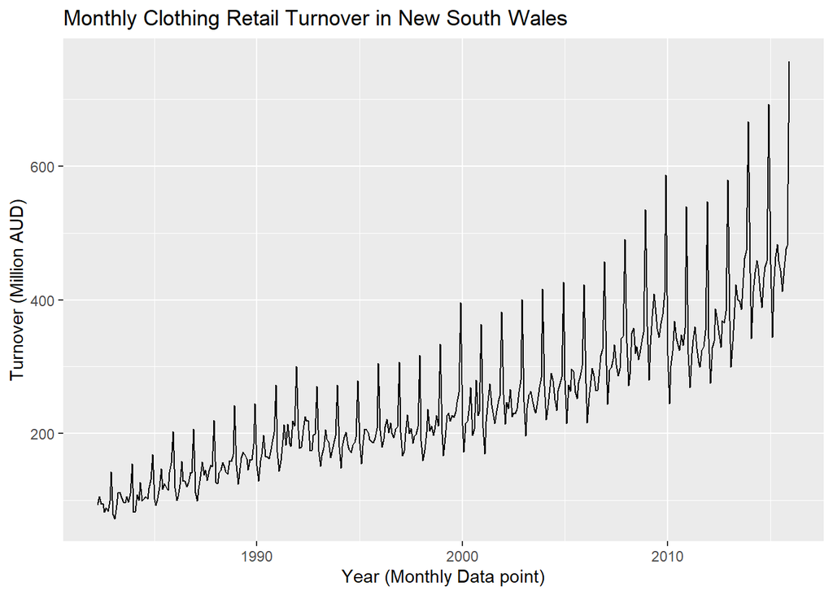

```r
library(fpp3)
library(readabs)
library(tsibble)
library(tseries)


set.seed(28768671)
myseries <- aus_retail %>%
  filter(
    `Series ID` == sample(aus_retail$`Series ID`,1),
    Month < yearmonth("2018 Jan")
  )


train <- myseries %>%
  filter(Month <= max(Month)-24)


train %>% autoplot(Turnover)+
  ggtitle("Monthly Clothing Retail Turnover in New South Wales") +
  ylab("Turnover (Million AUD)")+
  xlab("Year (Monthly Data point)")
```

By examining the data, there are several features that I need to take into account when modelling. First is a strong presence heteroskedasticity where variation in the data when turnover is low is much less than the variation with turnover is high. This can be adjusted with a Box-Cox transformation. Other features include a clear trend that seems to be dampening towards the end and clear seassonaility.

```r
lambda = train %>% features(Turnover, features = guerrero)
lambda$lambda_guerrero
```

```
## [1] -0.03429885
```

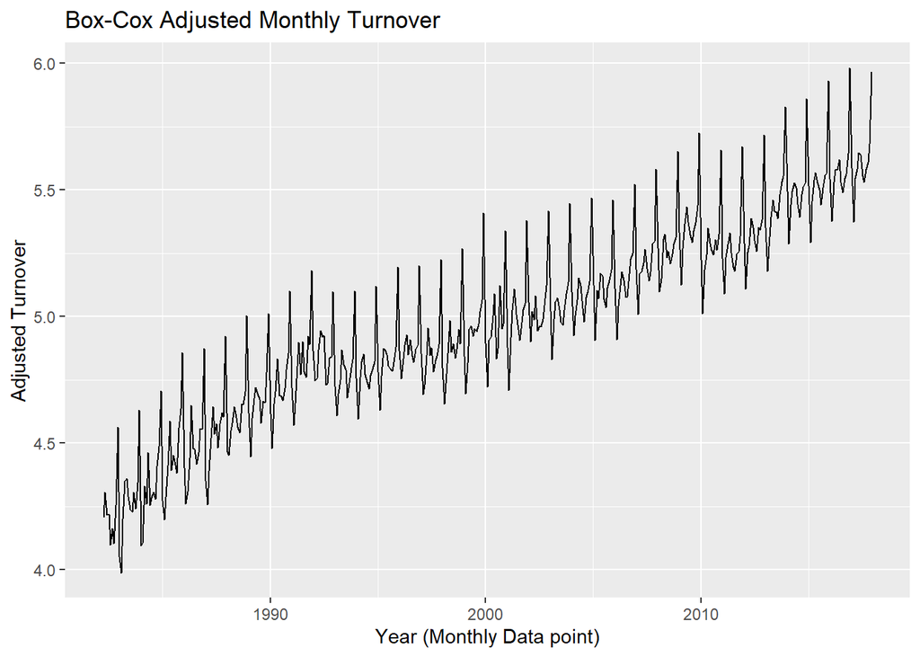

```r
myseries %>% autoplot(box_cox(Turnover, lambda$lambda_guerrero)) +
  ggtitle("Box-Cox Adjusted Monthly Turnover")+
  xlab("Year (Monthly Data point)")+
  ylab("Adjusted Turnover")
```

The heteroskedasticity seems to be taken care of and the variance is now stablised.

## ETS

### Model Selection

When choosing an ETS model, the model should include all level, trend and seasonality as the data contains these components. As the data is strictly positive, both additive and multiplicative errors can be used. For the trend component, both additive and additive damped can be tested as the data does display dampening towards the end. For seasonality, both additive and multiplicative can be tested, however, the combination of additive error and multiplicative seasonality should be avoided as they can be unstable.

Here I attempted all the available models:

```r
ets_fit<- train %>% model(
  auto = ETS(box_cox(Turnover, -0.03429885)),
  AAA = ETS(box_cox(Turnover, -0.03429885) ~ error("A") + trend("A") + season("A")),
  AAdA = ETS(box_cox(Turnover, -0.03429885) ~ error("A") + trend("Ad") + season("A")),
  MAA = ETS(box_cox(Turnover, -0.03429885) ~ error("M") + trend("A") + season("A")),
  MAdA = ETS(box_cox(Turnover, -0.03429885) ~ error("M") + trend("Ad") + season("A")),
  MAM = ETS(box_cox(Turnover, -0.03429885) ~ error("M") + trend("A") + season("M")),
  MAdM = ETS(box_cox(Turnover, -0.03429885) ~ error("M") + trend("Ad") + season("M"))
  )
select(glance(ets_fit), -State, - Industry)
```

```
## # A tibble: 7 x 9
##   .model    sigma2 log_ik    AIC   AICc   BIC     MSE    AMSE     MAE
##   <chr>      <dbl>  <dbl>  <dbl>  <dbl> <dbl>   <dbl>   <dbl>   <dbl>
## 1 auto   0.00226    26.5  -19.0  -17.4   49.1 0.00217 0.00243 0.0355
## 2 AAA    0.00226    26.5  -19.0  -17.4   49.1 0.00217 0.00243 0.0355
## 3 AAdA   0.00229    24.0  -12.0  -10.2   60.1 0.00219 0.00249 0.0359
## 4 MAA    0.0000989  14.1    5.88   7.46  73.9 0.00216 0.00243 0.00734
## 5 MAdA   0.0000996  13.6    8.88  10.7   81.0 0.00218 0.00247 0.00741
## 6 MAM    0.000102    7.47  19.1   20.6   87.1 0.00225 0.00251 0.00753
## 7 MAdM   0.000105    2.39  31.2   33.0  103.  0.00230 0.00260 0.00757
```

The ETS function as chosen a model has automatically chosen the model with lowest AICc value, which is the AAA. However, the dampened AAdA model is closely behind and it would be possible for a dampened model can product a better forecast, therefore they are both included in the subsequent analysis.

### Forecasting

```r
ets_aaa <- train %>% model(ETS(box_cox(Turnover, -0.03429885) ~ error("A") + trend("A") + season("A")))
ets_aada <- train %>% model(ETS(box_cox(Turnover, -0.03429885) ~ error("A") + trend("Ad") + season("A")))
ets_aaa_fc <- ets_aaa %>% forecast(h =24)
ets_aada_fc <- ets_aada %>% forecast(h =24)
```

#### ETS(A,A,A) Model

```r
ets_aaa_fc %>% accuracy(myseries)
```

```
## # A tibble: 1 x 11
##   .model       State  Industry .type    ME  RMSE   MAE    MPE  MAPE  MASE   ACF1
##   <chr>        <chr>  <chr>    <chr> <dbl> <dbl> <dbl>  <dbl> <dbl> <dbl>  <dbl>
## 1 "ETS(box_co~ New S~ Clothin~ Test  -2.65  18.4  16.2 -0.530  3.16 0.870 0.0857
```

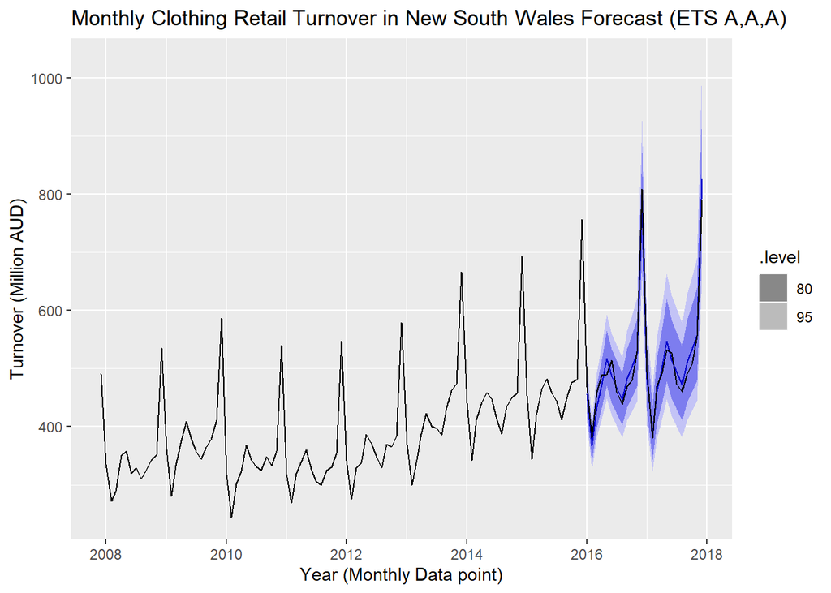

```r
ets_aaa_fc %>% autoplot(myseries %>%
                      filter(Month >= max(Month)-120)) +
  ggtitle("Monthly Clothing Retail Turnover in New South Wales Forecast (ETS A,A,A)") +
  ylab("Turnover (Million AUD)")+
  xlab("Year (Monthly Data point)")
```

#### ETS(A,Ad,A) Model

```r
ets_aada_fc %>% accuracy(myseries)
```

```
## # A tibble: 1 x 11
##   .model       State  Industry .type    ME  RMSE   MAE   MPE  MAPE  MASE    ACF1
##   <chr>        <chr>  <chr>    <chr> <dbl> <dbl> <dbl> <dbl> <dbl> <dbl>   <dbl>
## 1 "ETS(box_co~ New S~ Clothin~ Test   14.9  22.0  17.6  2.81  3.38 0.949 -0.0647
```

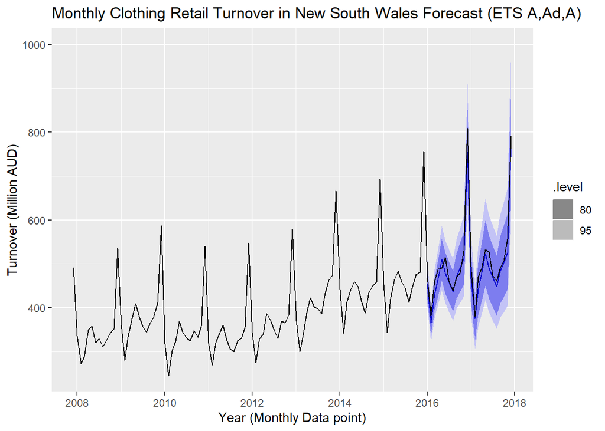

```r
ets_aada_fc %>% autoplot(myseries %>%
                      filter(Month >= max(Month)-120)) +
  ggtitle("Monthly Clothing Retail Turnover in New South Wales Forecast (ETS A,Ad,A)") +
  ylab("Turnover (Million AUD)")+
  xlab("Year (Monthly Data point)")
```

Both of the models was able to produce decent and similar forecastes. The model was able to predict the seasonality and the upward trend, most of the actual Turnover level is also within the 80% interval. Between the two models, the ETS(A,A,A) model achieved lower MASE and considering the lower AICc value for fitting the entire dataset, it was chosen to be the best ETS model.

#### Estimated Parameters for ETS(A,A,A) Model

```r
report(ets_aaa)
```

```
## Series: Turnover
## Model: ETS(A,A,A)
## Transformation: box_cox(.x, -0.03429885)
##   Smoothing parameters:
##     alpha = 0.3403724
##     beta  = 0.0001000527
##     gamma = 0.06425056
##
##   Initial states:
##         l           b         s1         s2          s3        s4         s5
##  4.200808 0.003636355 -0.0740141 -0.2082678 -0.05471782 0.3544658 0.05402661
##          s6          s7          s8          s9          s10        s11
##  0.01240679 -0.02613186 -0.07373826 -0.02626615 -0.003306868 0.07211925
##          s12
##  -0.02657551
##
##   sigma^2:  0.0023
##
##       AIC      AICc       BIC
## -18.98501 -17.40362  49.08107
```

### Residual Diagnostics

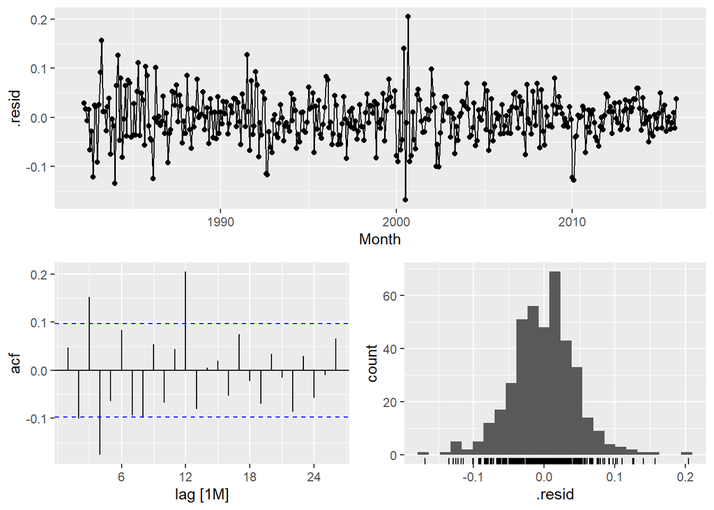

```r
gg_tsresiduals(ets_aaa)
```

```r
augment(ets_aaa) %>%
  features(.resid, ljung_box, lag=24, dof=3)
```

```
## # A tibble: 1 x 5
##   State      Industry     .model                              lb_stat  lb_pvalue
##   <chr>      <chr>        <chr>                                 <dbl>      <dbl>
## 1 New South~ Clothing re~ "ETS(box_cox(Turnover, -0.03429885~    75.8    4.07e-8
```

```r
augment(ets_aaa)$.resid %>%
  mean()
```

```
## [1] -0.0008745115
```

```r
augment(ets_aaa)$.resid %>%
  jarque.bera.test()
```

```
##
##  Jarque Bera Test
##
## data:  .
## X-squared = 38.944, df = 2, p-value = 3.494e-09
```

The residuals of the model is not well behaved, although the residual series mostly resembles white noise, it also show signs of heteroskedasticity where variance at the start of the series is stronger than variance towards the end, this can result in inaccuract prediction intervals. Possible solution is a reduction in strength of the Box-Cox transformation.

The ACF plot also shows autocorrelation in the lagged residuals, which is confirmed by a Ljung-Box test with p-value of 4.07e-8. This suggests that there are more available information in the residuals not captured by the model and the model could be improved. The distribution of the residuals is very close to 0, suggesting unbiasedness. The Jarque-Bera test with p-value of 3.494e-09 suggest that We have sufficient evidence to reject normality at 5% significance level, which will again impact our prediction intervals.

## ARIMA

### Model Selection

The ARIMA method also uses the Box-Cox transformed training set so the variance is stable, then we find the appropiate differencing order to stablise the mean.

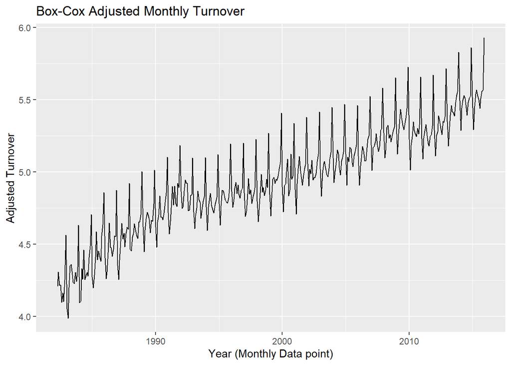

```r
train %>% autoplot(box_cox(Turnover, -0.03429885)) +
  ggtitle("Box-Cox Adjusted Monthly Turnover")+
  xlab("Year (Monthly Data point)")+
  ylab("Adjusted Turnover")
```

As there are strong seasonality, the seasonal difference is checked first as it is possible that normal differencing is not required after seasonal differencing.

```r
train %>% features(box_cox(Turnover, -0.03429885), list(unitroot_nsdiffs, feat_stl))
```

```
## # A tibble: 1 x 12
##   State Industry nsdiffs trend_strength seasonal_streng~ seasonal_peak_y~
##   <chr> <chr>      <int>          <dbl>            <dbl>            <dbl>
## 1 New ~ Clothin~       1          0.990            0.932                9
## # ... with 6 more variables: seasonal_trough_year <dbl>, spikiness <dbl>,
## #   linearity <dbl>, curvature <dbl>, stl_e_acf1 <dbl>, stl_e_acf10 <dbl>
```

Seasonal strength > 0.64, applying 1 seasonal difference

```r
train %>% features(difference(box_cox(Turnover, -0.03429885),12) , unitroot_nsdiffs)
```

```
## # A tibble: 1 x 3
##   State           Industry           nsdiffs
##   <chr>           <chr>                <int>
## 1 New South Wales Clothing retailing       0
```

Applying 1 seasonal differencing was sufficient to stablise the seasonal component as the nsdiffs value is now 0. Then I checked if more differenceing is required for the non-seasonal component.

```r
train %>% features(difference(box_cox(Turnover, -0.03429885),12) , unitroot_kpss)
```

```
## # A tibble: 1 x 4
##   State           Industry           kpss_stat kpss_pvalue
##   <chr>           <chr>                  <dbl>       <dbl>
## 1 New South Wales Clothing retailing     0.342         0.1
```

Seasonal differencing was sufficient to stablise the mean as suggested by the unit root test with p-value of 0.1. More differencing is not required. Next I try to determine which ARIMA model would be appropiate by examining the autocorrelation structure of the data.

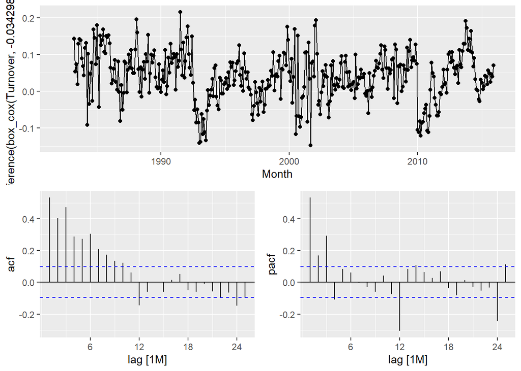

```r
train %>% gg_tsdisplay(difference(box_cox(Turnover, -0.03429885), 12), plot_type='partial')
```

The ACF and PACF plots provide clues for the order of AR and MA terms in an ARIMA model. The ACF plot demonstrates exponentially decaying correlations, which are significant up to lag 10. This pattern typically suggests an MA component because the autocorrelations die out after a certain number of lags.

In contrast, the PACF plot reveals significant correlations up to lag 4 and then cuts off, which is a classic indicator of an AR(4) process.

For the case presented, the AR(4) model is indicated by the PACF. However, despite the ACF suggesting an MA component, the specific order of MA(q) is less clear. Since the ACF does not cut off sharply, this implies a blend of AR and MA processes. Thus, some trial and error with various combinations of AR and MA terms may be necessary, followed by validation checks to ensure the best fitting model is selected.

For the seasonal component, there are significant lags at 12 and 24 for both the ACF and PACF, so both seasonal AR and seasonal MA will have to be tested.

```r
arima_fit <- train %>% model(
  arima_400_011 = ARIMA(box_cox(Turnover, -0.03429885) ~ 1 + pdq(4,0,0)+ PDQ(0,1,1)),
  arima_400_012 = ARIMA(box_cox(Turnover, -0.03429885) ~ 1 + pdq(4,0,0)+ PDQ(0,1,2)),
  arima_400_110 = ARIMA(box_cox(Turnover, -0.03429885) ~ 1 + pdq(4,0,0)+ PDQ(1,1,0)),
  arima_400_210 = ARIMA(box_cox(Turnover, -0.03429885) ~ 1 + pdq(4,0,0)+ PDQ(2,1,0)),
  arima_400_111 = ARIMA(box_cox(Turnover, -0.03429885) ~ 1 + pdq(4,0,0)+ PDQ(1,1,1)),
  arima_400_212 = ARIMA(box_cox(Turnover, -0.03429885) ~ 1 + pdq(4,0,0)+ PDQ(2,1,2)),
)
select(glance(arima_fit), -State, - Industry)
```

```
## # A tibble: 6 x 8
##   .model         sigma2 log_lik    AIC   AICc    BIC ar_roots   ma_roots
##   <chr>           <dbl>   <dbl>  <dbl>  <dbl>  <dbl> <list>     <list>
## 1 arima_400_011 0.00211    649. -1285. -1285. -1257. <cpl [4]>  <cpl [12]>
## 2 arima_400_012 0.00202    658. -1300. -1299. -1268. <cpl [4]>  <cpl [24]>
## 3 arima_400_110 0.00261    613. -1213. -1212. -1185. <cpl [16]> <cpl [0]>
## 4 arima_400_210 0.00235    633. -1250. -1249. -1218. <cpl [28]> <cpl [0]>
## 5 arima_400_111 0.00204    656. -1296. -1296. -1265. <cpl [16]> <cpl [12]>
## 6 arima_400_212 0.00202    660. -1299. -1299. -1259. <cpl [28]> <cpl [24]>
```

It seems the best performing model based on AICc is ARIMA(4,0,0)(0,1,2), the model space is explored further by altering the non-seasonal components.

```r
arima_fit <- train %>% model(
  arima_400_012 = ARIMA(box_cox(Turnover, -0.03429885) ~ 1 + pdq(4,0,0)+ PDQ(0,1,2)),
  arima_401_012 = ARIMA(box_cox(Turnover, -0.03429885) ~ 1 + pdq(4,0,1)+ PDQ(0,1,2)),
  arima_402_012 = ARIMA(box_cox(Turnover, -0.03429885) ~ 1 + pdq(4,0,2)+ PDQ(0,1,2)),
  arima_500_012 = ARIMA(box_cox(Turnover, -0.03429885) ~ 1 + pdq(5,0,0)+ PDQ(0,1,2)),
  arima_501_012 = ARIMA(box_cox(Turnover, -0.03429885) ~ 1 + pdq(5,0,1)+ PDQ(0,1,2)),
  arima_502_012 = ARIMA(box_cox(Turnover, -0.03429885) ~ 1 + pdq(5,0,2)+ PDQ(0,1,2)),
  arima_300_012 = ARIMA(box_cox(Turnover, -0.03429885) ~ 1 + pdq(3,0,0)+ PDQ(0,1,2)),
  arima_301_012 = ARIMA(box_cox(Turnover, -0.03429885) ~ 1 + pdq(3,0,1)+ PDQ(0,1,2)),
  arima_302_012 = ARIMA(box_cox(Turnover, -0.03429885) ~ 1 + pdq(3,0,2)+ PDQ(0,1,2)),
)

select(glance(arima_fit), -State, - Industry)
```

```
## # A tibble: 9 x 8
##   .model         sigma2 log_lik    AIC   AICc    BIC ar_roots  ma_roots
##   <chr>           <dbl>   <dbl>  <dbl>  <dbl>  <dbl> <list>    <list>
## 1 arima_400_012 0.00202    658. -1300. -1299. -1268. <cpl [4]> <cpl [24]>
## 2 arima_401_012 0.00201    659. -1300. -1300. -1264. <cpl [4]> <cpl [25]>
## 3 arima_402_012 0.00199    660. -1300. -1300. -1261. <cpl [4]> <cpl [26]>
## 4 arima_500_012 0.00198    662. -1306. -1305. -1270. <cpl [5]> <cpl [24]>
## 5 arima_501_012 0.00197    664. -1308. -1308. -1269. <cpl [5]> <cpl [25]>
## 6 arima_502_012 0.00197    664. -1306. -1306. -1263. <cpl [5]> <cpl [26]>
## 7 arima_300_012 0.00203    657. -1300. -1299. -1272. <cpl [3]> <cpl [24]>
## 8 arima_301_012 0.00201    659. -1302. -1301. -1270. <cpl [3]> <cpl [25]>
## 9 arima_302_012 0.00200    660. -1302. -1302. -1266. <cpl [3]> <cpl [26]>
```

Currently ARIMA(5,0,1)(0,1,2) is the best performing model based on AICc, an extended search with automatic ARIMA is performed to check if any better ARIMA model is available.

```r
auto_arima <- train %>% model(
  ARIMA(box_cox(Turnover, -0.03429885),  stepwise = FALSE,
               approximation = FALSE,
               order_constraint = p + q + P + Q <= 9))

auto_arima %>% report
```

```
## Series: Turnover
## Model: ARIMA(5,0,1)(2,1,1)[12] w/ drift
## Transformation: box_cox(.x, -0.03429885)
##
## Coefficients:
##          ar1      ar2     ar3      ar4     ar5      ma1    sar1     sar2
##       1.0977  -0.2691  0.3447  -0.3901  0.1918  -0.6327  0.1695  -0.1641
## s.e.  0.1893   0.1056  0.0723   0.0955  0.0516   0.1899  0.0635   0.0608
##          sma1  constant
##       -0.8308     1e-03
## s.e.   0.0468     2e-04
##
## sigma^2 estimated as 0.001954:  log likelihood=666.08
## AIC=-1310.16   AICc=-1309.46   BIC=-1266.45
```

The automatic ARIMA function found the best model to be ARIMA(5,0,1)(2,1,1), which has a slightly better AICc score. Although there is an increase in complexity of the model, the AICc score suggests it is justified by the increase in log likelihood. This model is selected to be the best ARIMA model.

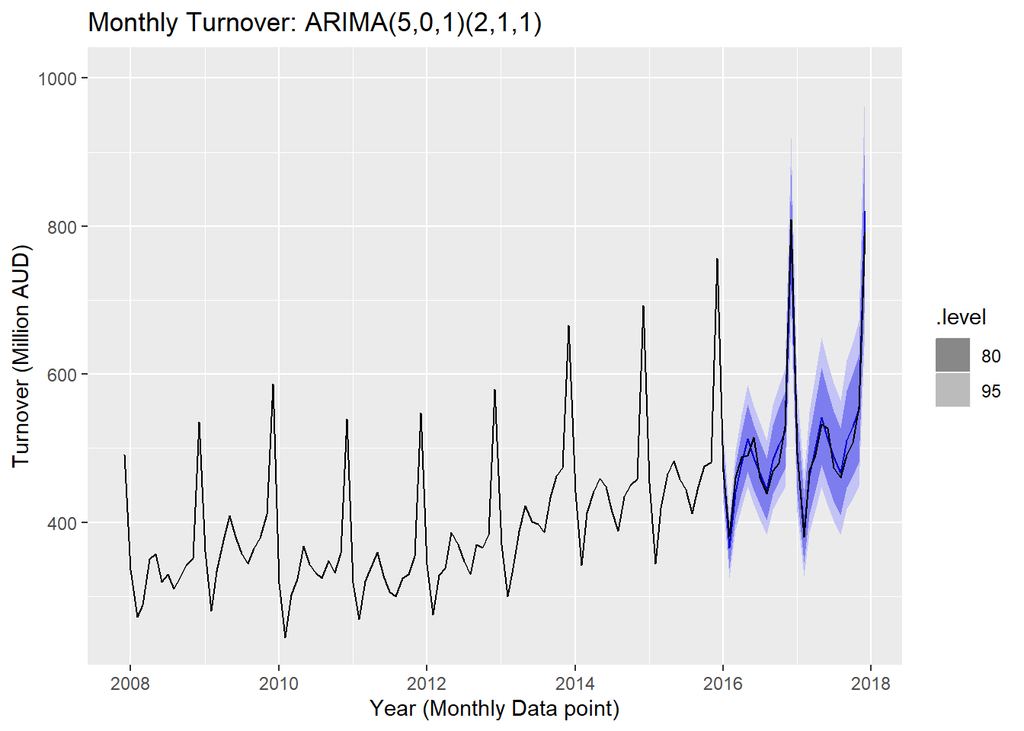

```r
arima_best <- train %>% model(
  ARIMA(box_cox(Turnover, -0.03429885) ~ 1 + pdq(5,0,1)+ PDQ(2,1,1)))
arima_fc <- arima_best %>% forecast(h =24)

arima_fc %>% autoplot(myseries %>%
                           filter(Month >= max(Month)-120)) +
  ggtitle("Monthly Turnover: ARIMA(5,0,1)(2,1,1)") +
  ylab("Turnover (Million AUD)")+
  xlab("Year (Monthly Data point)")
```

```r
arima_fc %>% accuracy(myseries)
```

```
## # A tibble: 1 x 11
##   .model      State  Industry .type    ME  RMSE   MAE    MPE  MAPE  MASE    ACF1
##   <chr>       <chr>  <chr>    <chr> <dbl> <dbl> <dbl>  <dbl> <dbl> <dbl>   <dbl>
## 1 "ARIMA(box~ New S~ Clothin~ Test  -2.68  15.7  13.6 -0.536  2.66 0.731 -0.0272
```

The forecast also performed very well and is able to capture the increasing trend and seasonality in the test dataset. The test set are also within the 80% prediction interval. The MASE value is very low at 0.73, which is even lower than the best of ETS models.

#### Estimated Parameters for ARIMA(5,0,1)(2,1,1) Model

```r
report(arima_best)
```

```
## Series: Turnover
## Model: ARIMA(5,0,1)(2,1,1)[12] w/ drift
## Transformation: box_cox(.x, -0.03429885)
##
## Coefficients:
##          ar1      ar2     ar3      ar4     ar5      ma1    sar1     sar2
##       1.0977  -0.2691  0.3447  -0.3901  0.1918  -0.6327  0.1695  -0.1641
## s.e.  0.1893   0.1056  0.0723   0.0955  0.0516   0.1899  0.0635   0.0608
##          sma1  constant
##       -0.8308     1e-03
## s.e.   0.0468     2e-04
##
## sigma^2 estimated as 0.001954:  log likelihood=666.08
## AIC=-1310.16   AICc=-1309.46   BIC=-1266.45
```

### Residual Diagnostics

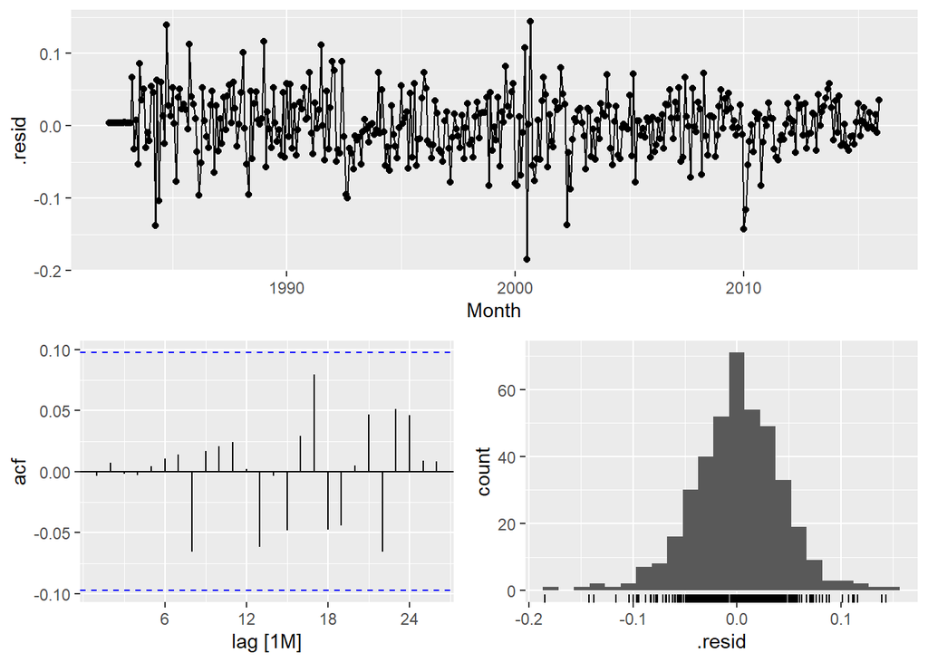

```r
arima_best %>% gg_tsresiduals()
```

```r
augment(arima_best) %>%
  features(.resid, ljung_box, lag=24, dof=10)
```

```
## # A tibble: 1 x 5
##   State      Industry     .model                               lb_stat lb_pvalue
##   <chr>      <chr>        <chr>                                  <dbl>     <dbl>
## 1 New South~ Clothing re~ "ARIMA(box_cox(Turnover, -0.0342988~    14.8     0.390
```

By examining the residual plot, the residuals seem to be well behaved, resembling white noise, centering at zero and having near constant volatility. The distribution of the residuals also seems normal. The ACF shows no significant lags, suggesting no auto correlation and all information in the lags is captured by the model. This is supported by the Ljung-Box test with p-value of 0.39.

## Comparing ETS and ARIMA Forecasts

While both models producted similar forecast and were both fairly accurate with low MASE, the ARIMA model was able to perform slightly better with lower MASE. The ARIMA model was also able to capture more information in the data as the residuals were not correlated.

## Out of Sample Forecasts

Creating the forecasts:

```r
ets_fit <- myseries %>% model(ETS(box_cox(Turnover, -0.03429885) ~ error("A") + trend("A") + season("A")))
ets_fc <- ets_fit %>% forecast(h =24)


arima_fit <- myseries %>% model(
  ARIMA(box_cox(Turnover, -0.03429885) ~ 1 + pdq(5,0,1)+ PDQ(2,1,1)))
arima_fc <- arima_fit %>% forecast(h =24)
```

Obtaining the out of sample data:

```r
retail_data = read_abs(8501.0, tables = 11)
retail_ts <- retail_data %>%
  filter(series_id == "A3349399C") %>%
  add_column(State = "New South Wales", Industry = "Clothing retailing") %>%
  mutate(Month = yearmonth(date), Turnover = value) %>%
  select(-table_no, -sheet_no, -table_title, -series, -date, -value) %>%
  as_tsibble(key = c(State, Industry), index = Month)
```

Comparing the forecasts:

ETS:

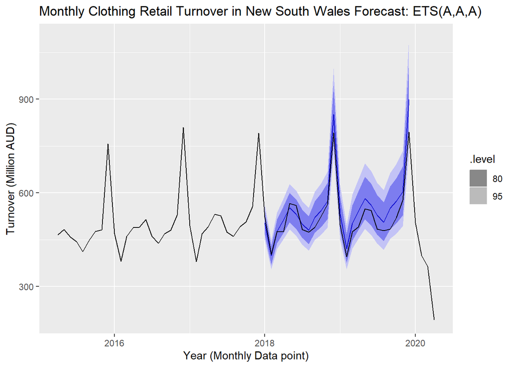

```r
ets_fc %>% autoplot(retail_ts %>%
  filter(Month >= max(Month)-60)) +
  ggtitle("Monthly Clothing Retail Turnover in New South Wales Forecast: ETS(A,A,A)") +
  ylab("Turnover (Million AUD)")+
  xlab("Year (Monthly Data point)")
```

```r
ets_fc %>% accuracy(retail_ts)
```

```
## # A tibble: 1 x 11
##   .model         State  Industry .type    ME  RMSE   MAE   MPE  MAPE  MASE  ACF1
##   <chr>          <chr>  <chr>    <chr> <dbl> <dbl> <dbl> <dbl> <dbl> <dbl> <dbl>
## 1 "ETS(box_cox(~ New S~ Clothin~ Test  -26.1  38.7  31.4 -4.79  5.78  1.66 0.251
```

ARIMA:

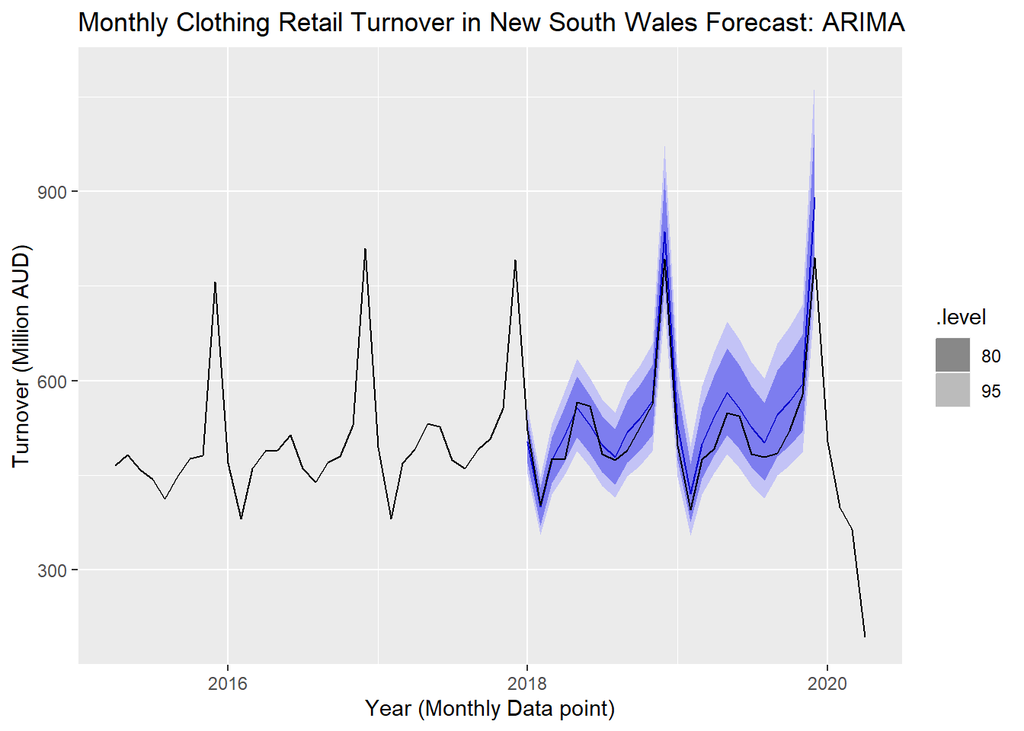

```r
arima_fc %>% autoplot(retail_ts %>%
  filter(Month >= max(Month)-60)) +
  ggtitle("Monthly Clothing Retail Turnover in New South Wales Forecast: ARIMA") +
  ylab("Turnover (Million AUD)")+
  xlab("Year (Monthly Data point)")
```

```r
arima_fc %>% accuracy(retail_ts)
```

```
## # A tibble: 1 x 11
##   .model         State  Industry .type    ME  RMSE   MAE   MPE  MAPE  MASE  ACF1
##   <chr>          <chr>  <chr>    <chr> <dbl> <dbl> <dbl> <dbl> <dbl> <dbl> <dbl>
## 1 "ARIMA(box_co~ New S~ Clothin~ Test  -22.9  35.2  28.1 -4.25  5.22  1.49 0.188
```

Both models produced similar forecasts as they were trained on the same data set. They both predicted well the turnover in 2018 and over predicted in 2019 where the seasonal pattern was still similar to previous years yet the increasing trend in overall turnover was dampening. Both predictions were still relatively accurate with the actual values mostly lying within the 80% prediction interval. The ARIMA model performed slightly better with MASE of 1.49 compared to ETS model having a MASE of 1.66.

## Conclusions

Overall, the ARIMA models were able to perform better in modeling the data and forecasting. The ARIMA model can be more adaptable, with infinite possible variations in regressors to handle the patterns and autocorrelations in the data, where as the ETS models are more limited in customisability with the set of possible models. However, the ARIMA models require much more computation and larger samples. The differencing and seasonal differencing required to achieve stationarity can consume a large portion of the sample data. The large model space also means more computation and experimenting is required to find the appropiate model, while the ETS method can simply test all possible models and find the best variation easily.

Both models are limited in that they rely only on information present in past data, they cannot predict variations caused by events outside the past data. A clear example would be the subsequent drop in turnover in 2020 resulted from COVID-19. The models will also have trouble predicting the turnover in 2021 as the estimated parameters derived from past data may bot be representative of the patterns in the future.